# Práctica de Regresión lineal simple y evaluación de supuestos

# INDEPENDENCIA: MÉTODO GRÁFICO

**H<sub>0</sub>**: Los residuos son independientes entre sí.

**H<sub>A</sub>**: Los residuos no son independientes entre sí (existe autocorrelación).

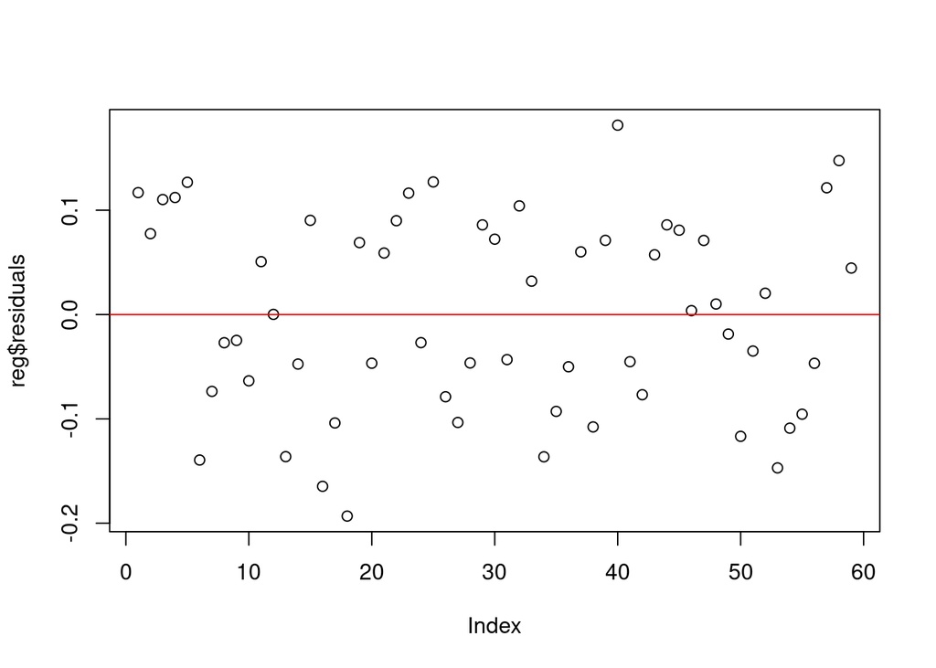

```r
plot(reg$residuals)
abline(h=0, col="red")
```

# INDEPENDENCIA: **PRUEBA DE DURBIN-WATSON**

```r
dwtest(`Global Temperature Anomalies`~ CO2_ppm,
       data = Global_warming,
       alternative = c("two.sided"),
       iterations = 15)
```

```
##
##  Durbin-Watson test
##
## data:  `Global Temperature Anomalies` ~ CO2_ppm
## DW = 1.5012, p-value = 0.03616
## alternative hypothesis: true autocorrelation is not 0
```

**Interpretación**

Como el p-valor (**0.03616**) es menor al nivel de significación ($\alpha$ =0.05) rechazamos la hipotesis nula. Por lo tanto, los residuos no son independientes, es decir, están correlacionados.

# LINEALIDAD: MÉTODO GRÁFICO

**H<sub>0</sub>**: Hay relación lineal entre la variable regresora y la variable predictora.

**H<sub>A</sub>**: No hay relación lineal entre la variable regresora y la variable predictora.

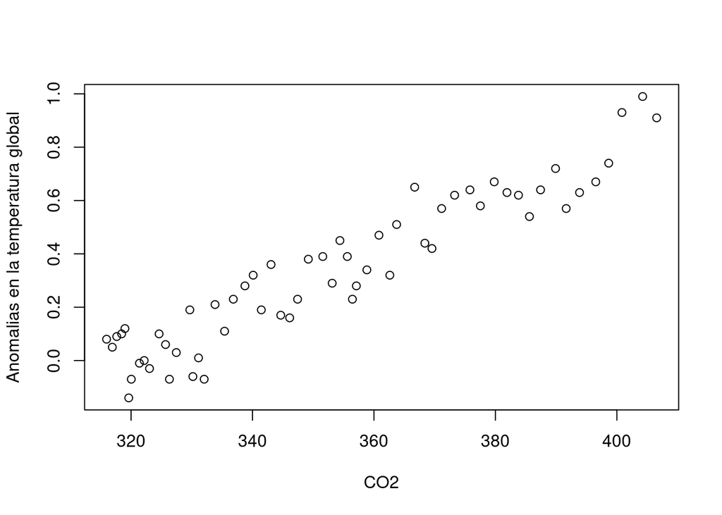

```r
plot(Global_warming$CO2_ppm,Global_warming$`Global Temperature Anomalies`, xlab="CO2", ylab = "Anomalias en la temperatura global")
```

# HOMOGENEIDAD DE VARIANZAS: MÉTODO GRÁFICO

**H<sub>0</sub>**: La varianza de los residuos es constante.

**H<sub>A</sub>**: La varianza de los residuos no es constante.

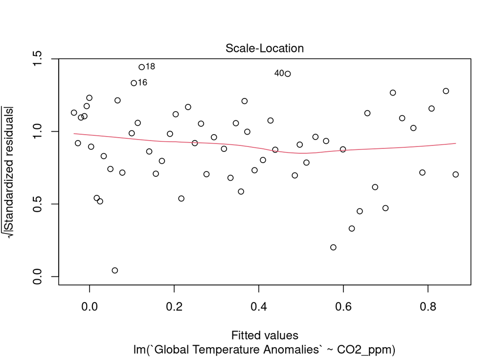

```r
plot(reg, which=3)
```

# HOMOGENEIDAD DE VARIANZAS: **PRUEBA DE BREUSCH-PAGAN**

```
##
##  studentized Breusch-Pagan test
##
## data:  reg
## BP = 0.34329, df = 1, p-value = 0.5579
```

**Interpretación**

Como el p-valor (**0.5579**) es mayor al nivel de significación ($\alpha$ =0.05) no hay evidencia para rechazar la hipotesis nula. Por lo tanto, la varianza de los residuos es constante.

# NORMALIDAD: GRÁFICO DE CUANTILES

**H<sub>0</sub>**: Los residuos tienen distribución normal.

**H<sub>A</sub>**: Los residuos no tienen distribución normal.

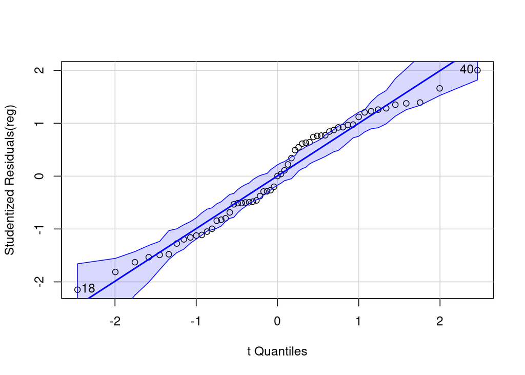

```
## [1] 18 40
```

```r
qqPlot(reg) # library(car)
```

# NORMALIDAD: **PRUEBA DE SHAPIRO-WILKS**

```r
shapiro.test(x= rstudent(reg)) # Se hizo la prueba de normalidad con los residuos estudentizados
```

```
##
##  Shapiro-Wilk normality test
##
## data:  rstudent(reg)
## W = 0.96581, p-value = 0.09589
```

**Interpretación**

Como el p-valor (**0.09589**) es mayor al nivel de significación ($\alpha$ =0.05) no hay evidencia para rechazar la hipotesis nula. Por lo tanto, los residuos tienen distribución normal.

# NORMALIDAD: HISTOGRAMA DE RESIDUALES

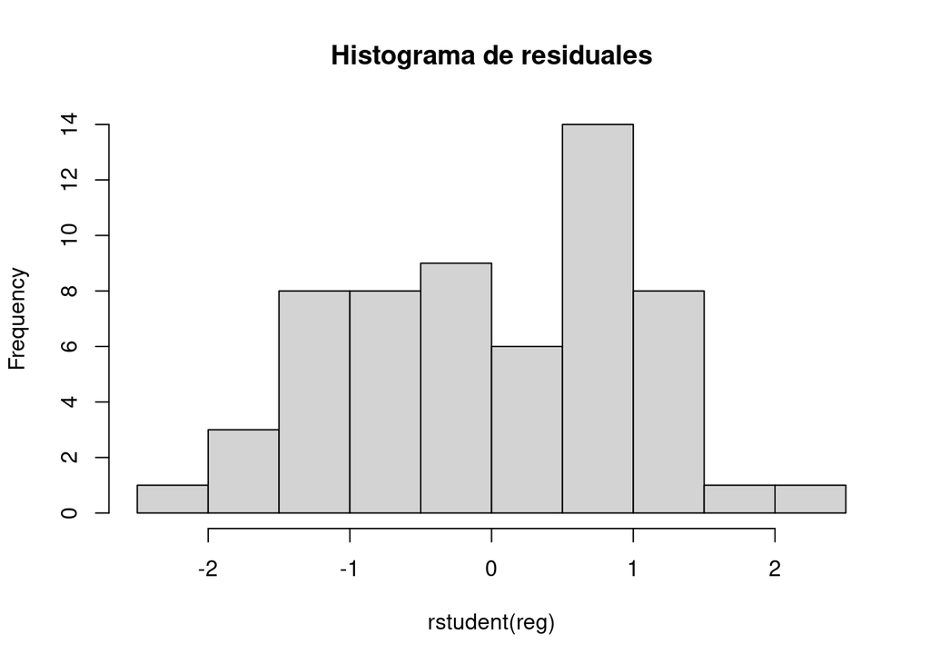

```r
hist(x= rstudent(reg), main = "Histograma de residuales")  # Se hizo el histograma de los residuos estudentizados
```

# VALORES ATÍPICOS: DISTANCIA DE COOK

Una observación se puede considerar influyente (valor atípico) si tiene un valor de **distancia de Cook mayor a 1**.

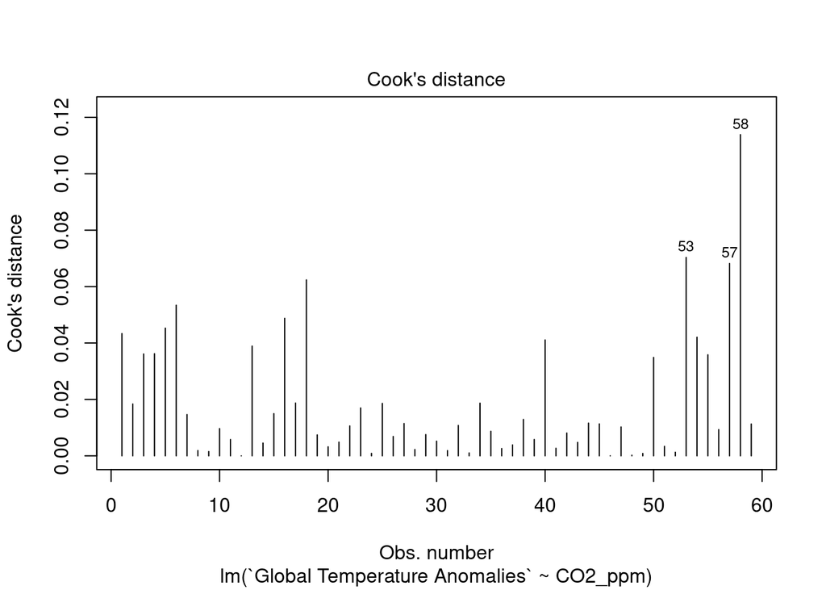

```r
plot(reg, which=4)
```

**INTERPRETACIÓN DE LA EVALUACIÓN DE LOS SUPUESTOS**

Debido a que el supuesto de independencia no se cumplió (resultado obtenido de la prueba de Durbin Watson) el modelo de regresión simple ajustado no sería la alternativa de análisis para este set de datos.